# Machine Learning: Введение.

### Откуда, что, почему и как жить дальше.

## Задачи, решаемые при помощи машинного обучения

##### Было:

[figure not shown]

## Задачи, решаемые при помощи машинного обучения

### Стало:

[figure not shown]

### Постановка задачи

1. На какой вопрос(ы) я пытаюсь ответить? Собранные данные могут ответить на этот вопрос?
2. Как лучше всего сформулировать свой вопрос(ы) с точки зрения задач машинного обучения?
3. У меня собрано достаточно данных, чтобы составить представление о задаче, которую я хочу решить?
4. Какие признаки я извлек и помогут ли они мне получить правильные прогнозы?
5. Как я буду измерять эффективность решения задачи?
6. Как решение, полученное с помощью машинного обучения, будет взаимодействовать с другими компонентами моего исследования или бизнес-продукта?

### А что .... python?

[figure not shown]

### Что нужно ?

```
pip install numpy scipy matplotlib ipython scikit-learn pandas mglearn
```

## NumPy

NumPy – это один из основных пакетов для научных вычислений в Python. Он содержит функциональные возможности для работы с многомерными массивами, высокоуровневыми математическими функциями (операции линейной алгебры, преобразование Фурье, генератор псевдослучайных чисел).

```python
import numpy as np
x = np.array([[1,2,3],[4,5,6]])
print("x:\n{}".format(x))
```

```
x:
[[1 2 3]
 [4 5 6]]
```

## SciPy

SciPy – это набор функций для научных вычислений в Python. Помимо всего прочего, он предлагает продвинутые процедуры линейной алгебры, математическую оптимизацию функций, обработку сигналов, специальные математические функции и статистические функции.

```python
from scipy import sparse
# Создаем 2D массив NumPy с единицами по главной диагонали и нулями в остальных ячейках
eye = np.eye(4)
print("массив NumPy:\n{}".format(eye))
```

```
массив NumPy:
[[1. 0. 0. 0.]
 [0. 1. 0. 0.]
 [0. 0. 1. 0.]
 [0. 0. 0. 1.]]
```

## matplotlib

matplotlib – это основная библиотека для построения научных графиков в Python. Она включает функции для создания высококачественных визуализаций типа линейных диаграмм, гистограмм, диаграмм разброса и т.д. Визуализация данных и различных аспектов вашего анализа может дать вам важную информацию, и мы будем использовать matplotlib для всех наших визуализаций

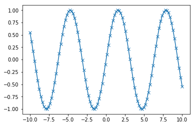

```python
%matplotlib inline
import matplotlib.pyplot as plt
# Генерируем последовательность чисел от -10 до 10 с 100 шагами
x = np.linspace(-10, 10, 100)
# Создаем второй массив с помощью синуса
y = np.sin(x)
# Функция создает линейный график на основе двух массивов
plt.plot(x, y, marker="x")
```

## pandas

pandas – библиотека Python для обработки и анализа данных. Она построена на основе структуры данных, называемой DataFrame и смоделированной по принципу датафреймов среды статистического программирования R. Проще говоря, DataFrame библиотеки pandas представляет собой таблицу, похожую на электронную таблицу Excel.

```python
import pandas as pd
# создаем простой набор данных с характеристиками пользователей
data = {'Name': ["John", "Anna", "Peter", "Linda"],
'Location' : ["New York", "Paris", "Berlin", "London"], 'Age' : [24, 13, 53, 33]
}
data_pandas = pd.DataFrame(data)
# IPython.display позволяет "красиво напечатать" датафреймы
# в Jupyter notebook
display(data_pandas)
```

|  | Name | Location | Age |
| --- | --- | --- | --- |
| 0 | John | New York | 24 |
| 1 | Anna | Paris | 13 |
| 2 | Peter | Berlin | 53 |
| 3 | Linda | London | 33 |

```python
# Выбрать все строки, в которых значение столбца age больше 30
display(data_pandas[data_pandas.Age > 30])
```

|  | Name | Location | Age |
| --- | --- | --- | --- |
| 2 | Peter | Berlin | 53 |
| 3 | Linda | London | 33 |

# Iris, первая задача классификации

Предположим, что вы внезапно решили стать ботаником, и решили классифицировать сорта ирисов, которые вы собрали. Измерили некоторые характеристики ирисов:

1. Длину и ширину лепестков
2. Длину и шиирну чашелистиков

[figure not shown]

Наша цель заключается в построении модели машинного обучения, которая сможет обучиться на основе характеристик ирисов, уже классифицированных по сортам, и затем предскажет сорт для нового цветка ириса.

#### Загрузка данных

Данные которые мы будем загружать - это набор Iris, это классический набор данных в машинном обучении и статистике. Он включен в модуль dataset.

```python
from sklearn.datasets import load_iris
iris_dataset = load_iris()
```

Объект iris, возвращаемый load_iris, является объектом Bunch, который очень похож на словарь. Он содержит ключи и значения:

```python
print("Ключи iris_dataset: \n{}".format(iris_dataset.keys()))
```

```
Ключи iris_dataset:
dict_keys(['data', 'target', 'target_names', 'DESCR', 'feature_names'])
```

```python
print(iris_dataset['DESCR'][:193] + "\n...")
```

```
Iris Plants Database
====================

Notes
-----
Data Set Characteristics:
    :Number of Instances: 150 (50 in each of three classes)
    :Number of Attributes: 4 numeric, predictive att
...
```

Значение ключа **target_names** – это массив строк, содержащий сорта цветов, которые мы хотим предсказать:

```python
print("Названия ответов: {}".format(iris_dataset['target_names']))
```

```
Названия ответов: ['setosa' 'versicolor' 'virginica']
```

Значение **feature_names** – это список строк с описанием каждого признака:

```python
print("Название празинаков:\n{}".format(iris_dataset['feature_names']))
```

```
Название празинаков:
['sepal length (cm)', 'sepal width (cm)', 'petal length (cm)', 'petal width (cm)']
```

Данные записаны в масивах target и data - NumPy массив, который содержит количественные измерения длины чашелистиков, ширины чашелистиков, длины лепестков и ширины лепестков. Посмотреть это можно через **type**

```python
print("Тип массива data: {}".format(type(iris_dataset['data'])))
```

```
Тип массива data: <class 'numpy.ndarray'>
```

```python
print("Форма массива data: {}".format(iris_dataset['data'].shape))
```

```
Форма массива data: (150, 4)
```

Выведем первые пять строк из обучающей выборки:

```python
print("Первые пять строк массива data:\n{}".format(iris_dataset['data'][:5]))
```

```
Первые пять строк массива data:
[[5.1 3.5 1.4 0.2]
 [4.9 3.  1.4 0.2]
 [4.7 3.2 1.3 0.2]
 [4.6 3.1 1.5 0.2]
 [5.  3.6 1.4 0.2]]
```

Массив **target** содержит сорта уже измеренных цветов, тоже записанные в виде NumPy массива.

```python
print("Форма массива target: {}".format(iris_dataset['target'].shape))
```

```
Форма массива target: (150,)
```

```python
print("Ответы :\n{}".format(iris_dataset['target']))
```

```
Ответы :
[0 0 0 0 0 0 0 0 0 0 0 0 0 0 0 0 0 0 0 0 0 0 0 0 0 0 0 0 0 0 0 0 0 0 0 0 0
 0 0 0 0 0 0 0 0 0 0 0 0 0 1 1 1 1 1 1 1 1 1 1 1 1 1 1 1 1 1 1 1 1 1 1 1 1
 1 1 1 1 1 1 1 1 1 1 1 1 1 1 1 1 1 1 1 1 1 1 1 1 1 1 2 2 2 2 2 2 2 2 2 2 2
 2 2 2 2 2 2 2 2 2 2 2 2 2 2 2 2 2 2 2 2 2 2 2 2 2 2 2 2 2 2 2 2 2 2 2 2 2
 2 2]
```

Значение чисел в миссиве **target**:  
0 - setosa  
1 - versicolor  
2 - virginica.

```python
## Обучающие данные и тестовые данные
```

В машином обучении данные, как правило, обозначаются заглавной Х, тогда как метки обозночаются строчной y. Это из стандартного вида функции f(x)=y, где x аргумент функции, а y - её значение. В соответсвии с правилами представления математических объектов, мы используем X, потому что данные представляют собой двумерный массив (матрицу), и строчную у - одномерный массив.

```python
from sklearn.model_selection import train_test_split
X_train, X_test, y_train, y_test = train_test_split(iris_dataset['data'], iris_dataset['target'], random_state=0)
```

```python
print("Форма массива  X_test: {}".format(X_test.shape))
print("Форма массива  y_test: {}".format(y_test.shape))
```

```
Форма массива  X_test: (38, 4)
Форма массива  y_test: (38,)
```

```python
print("Форма массива X_train: {}".format(X_train.shape))
print("Форма массива y_train: {}".format(y_train.shape))
```

```
Форма массива X_train: (112, 4)
Форма массива y_train: (112,)
```

## Посмотрим на данные.

Перед тем, как строить модель, давайте же вглянем, как выглядят наши данные, чтобы понять, возможно ли вообще выделить в них какие-либо зависимости. Кроме того, исследование данных - это хороший способ обнаружить аномалии и особенности. Например, вполне возомжно, что некторые из ирисов измерены в дюймах, а не в сантиметрах. В реальной жизни несостыковки проявляют себя с большой частотой.

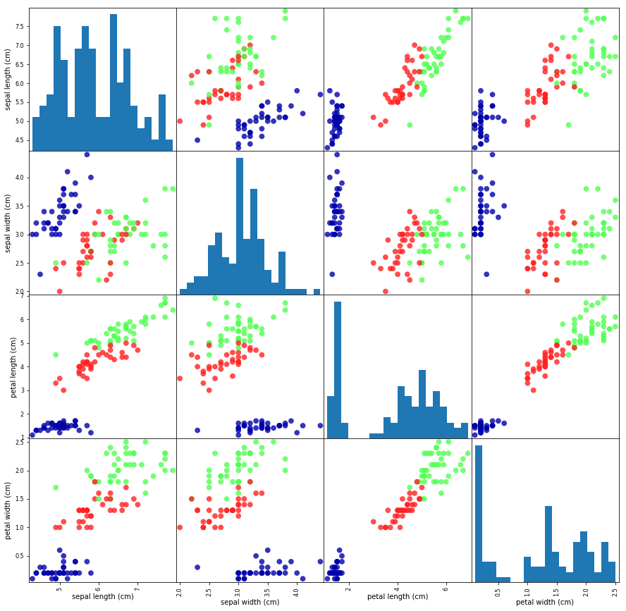

```python
import mglearn
# создаем dataframe из данных в массиве X_train
# маркируем столбцы, используя строки в iris_dataset.feature_names
iris_dataframe = pd.DataFrame(X_train, columns=iris_dataset.feature_names)
# создаем матриуц рессеяния из dataframe, цвет точек задается с помощью y_train
grr = pd.scatter_matrix(iris_dataframe, c=y_train, figsize=(15, 15), marker='o', hist_kwds={'bins': 20}, s=60, alpha=.8, cmap=mglearn.cm3)
```

## Первая ваш модель: метод k ближайших соседей

[figure not shown]

Самым важным параметром KNeighborsClassifier является количество соседей, которые мы установим равным 1:

```python
from sklearn.neighbors import KNeighborsClassifier
knn = KNeighborsClassifier(n_neighbors=1)
```

```python
knn.fit(X_train, y_train)
```

```
KNeighborsClassifier(algorithm='auto', leaf_size=30, metric='minkowski',
           metric_params=None, n_jobs=1, n_neighbors=1, p=2,
           weights='uniform')
```

## Прогнозируем, но не как росгидромедцентр.

Теперь мы можем получить прогнозы, применив модель к новым данным, по которым мы еще не знаем результатов.

Давайте представим, что вы опять решили занятся этим делом и сделали пару измерений.

Пример: длина чашелистика 5 см, ширина чашелистика 2.9 см, длина лепестка 1 см и ширина лепестка 0.2 см.

К какому сорту ириса можно отнести этот цветок?

```python
X_new = np.array([[5, 2.9, 1, 0.2]])
print("Форма массива X_new: {}".format(X_new.shape))
```

```
Форма массива X_new: (1, 4)
```

Обратите внимание, что мы записали измерения по одному цветку в двумерный массив NumPy, поскольку scikit-learn работает с двумерными массивами данных.

```python
prediction = knn.predict(X_new)
print("Прогноз: {}".format(prediction))
print("Спрогнозированная метка: {}".format(iris_dataset['target_names'][prediction]))
```

```
Прогноз: [0]
Спрогнозированная метка: ['setosa']
```

Наша модель предсказывает, что этот новый цветок ириса принадлежит к классу 0, что означает сорт setosa. Но как узнать, можем ли мы доверять нашей модели?

## Качество модели

Мы можем оценить качество модели, вычислив **точность** (*accuracy*) – процент цветов, для которых модель правильно спрогнозировала сорта:

```python
y_pred = knn.predict(X_test)
print("Прогнозы для тестовго набора:\n {}".format(y_pred))
```

```
Прогнозы для тестовго набора:
 [2 1 0 2 0 2 0 1 1 1 2 1 1 1 1 0 1 1 0 0 2 1 0 0 2 0 0 1 1 0 2 1 0 2 2 1 0
 2]
```

```python
 print("Точность на тестовом наборе: {:.2f}".format(np.mean(y_pred == y_test)))
```

```
Точность на тестовом наборе: 0.97
```

Кроме того, мы можем использовать метод score объекта knn, который вычисляет правильность модели для тестового набора:

```python
print("Точность на тестовом наборе: {:.2f}".format(knn.score(X_test, y_test)))
```

```
Точность на тестовом наборе: 0.97
```

## HomeWork

В библиотеке sklearn.datasets cуществует еще тестовые выборки.

1. make_circles - создаст выборку из кругов
2. make_classification - создаст случайную задачу классификации из n-класса.
3. make_blobs - создаст изотропные гауссовы капли для кластеризации. Необходимо создать knn классификацию, и поиграть с параметрами создания обучающей выборки и как вилияет количество соседей на прогнозирование.

```python
from sklearn.datasets import make_blobs
X,y = make_blobs(random_state=1,n_samples=100, n_features=2, centers=4)
```

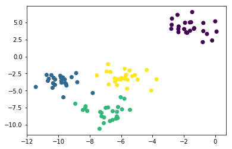

```python
#Взлянем на набор данных
plt.scatter(X[:, 0], X[:, 1], marker='o', c=y)
plt.show()
```

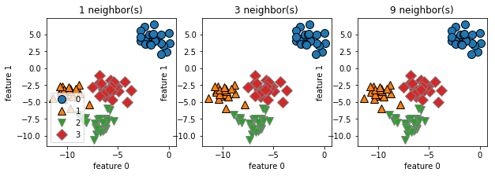

```python
fig, axes = plt.subplots(1, 3, figsize = (10, 3))

for n_neighbors, ax in zip([1, 3, 9], axes):
    clf = KNeighborsClassifier(n_neighbors=n_neighbors).fit(X, y)
    mglearn.discrete_scatter(X[:, 0], X[:, 1], y, ax=ax)
    ax.set_title("{} neighbor(s)".format(n_neighbors))
    ax.set_xlabel("feature 0")
    ax.set_ylabel("feature 1")
axes[0].legend(loc=3)
```

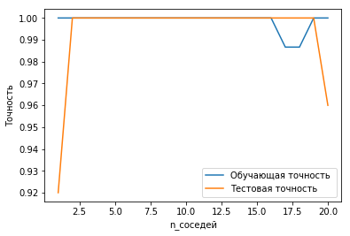

```python
X_train, X_test, y_train, y_test = train_test_split(X, y, random_state=2)

training_accuracy = []
test_accuracy = []
# Попробуй установить количество соседей (n_neighbors) от 1 до 10
neighbors_settings = range(1, 21)
for n_neighbors in neighbors_settings:
    # построить модель
    reg = KNeighborsClassifier(n_neighbors=n_neighbors)
    reg.fit(X_train, y_train)
    # запишем обучающую точность
    training_accuracy.append(reg.score(X_train, y_train))
    # запишем тестовую точность
    test_accuracy.append(reg.score(X_test, y_test))

plt.plot(neighbors_settings,
         training_accuracy, label="Обучающая точность ")
plt.plot(neighbors_settings,
        test_accuracy, label="Тестовая точность")
plt.ylabel("Точность")
plt.xlabel("n_соседей")
plt.legend()
```